# Project-4

Objective

To predict the concrete strength using the data available in file "concrete.csv". Apply feature engineering and model tuning to obtain 85% to 95% accuracy.

```python
import warnings
warnings.filterwarnings('ignore')   # to avoid warnings
```

```python
import pandas as pd


#Import Decision Tree Classifier machine learning Library
from sklearn.tree import DecisionTreeClassifier

# there are various other models that have been imported in the coming sections
# while doing the Model Tuning and hyper-parameters

#Import Sklearn package's data splitting function which is based on random function
from sklearn.model_selection import train_test_split

#Import the metrics
from sklearn import metrics


# importing ploting libraries
import matplotlib.pyplot as plt
# To enable plotting graphs in Jupyter notebook
%matplotlib inline

#importing seaborn for statistical plots
import seaborn as sns

#Let us break the X and y dataframes into training set and test set. For this we will use
#Sklearn package's data splitting function which is based on random function

from sklearn.model_selection import train_test_split

import numpy as np
from scipy import stats

# calculate accuracy measures and confusion matrix
from sklearn import metrics



pdata = pd.read_csv("concrete.csv")

print('Done importing packages...')
```

```
Done importing packages...
```

# Univariate analysis –

data types and description of the independent attributes which should include (name, range of values observed, central values (mean and median), standard deviation and quartiles, analysis of the body of distributions/tails, missing values, outliers, duplicates(10 Marks)

```python
# check datatype
pdata.info()
pdata.dtypes
```

```
<class 'pandas.core.frame.DataFrame'>
RangeIndex: 1030 entries, 0 to 1029
Data columns (total 9 columns):
 #   Column        Non-Null Count  Dtype
---  ------        --------------  -----
 0   cement        1030 non-null   float64
 1   slag          1030 non-null   float64
 2   ash           1030 non-null   float64
 3   water         1030 non-null   float64
 4   superplastic  1030 non-null   float64
 5   coarseagg     1030 non-null   float64
 6   fineagg       1030 non-null   float64
 7   age           1030 non-null   int64
 8   strength      1030 non-null   float64
dtypes: float64(8), int64(1)
memory usage: 72.5 KB
```

```
cement          float64
slag            float64
ash             float64
water           float64
superplastic    float64
coarseagg       float64
fineagg         float64
age               int64
strength        float64
dtype: object
```

```python
# change the data type to float32, as we might need to high memory for the modelling
pdata["cement"] = pdata["cement"].astype('float32')
pdata["slag"] = pdata["slag"].astype('float32')
pdata["ash"] = pdata["ash"].astype('float32')

pdata["water"] = pdata["water"].astype('float32')
pdata["superplastic"] = pdata["superplastic"].astype('float32')
pdata["coarseagg"] = pdata["coarseagg"].astype('float32')

pdata["fineagg"] = pdata["fineagg"].astype('float32')
pdata["age"] = pdata["age"].astype('int32')
pdata["strength"] = pdata["strength"].astype('float32')

pdata.dtypes
```

```
cement          float32
slag            float32
ash             float32
water           float32
superplastic    float32
coarseagg       float32
fineagg         float32
age               int32
strength        float32
dtype: object
```

```python
# statistical summary
pdata.describe(include='all').transpose()
pdata_ss =pdata.describe(include='all').transpose()
pdata_ss['Range_of_Values'] = pdata_ss['max']- pdata_ss['min']
print(pdata_ss)

# range of values observed = max- min
# central values (mean and median = 50% ), standard deviation and quartiles (25%, 50% and 75%)
```

```
               count        mean         std         min         25%  \
cement        1030.0  281.167877  104.506294  102.000000  192.375000
slag          1030.0   73.895828   86.279190    0.000000    0.000000
ash           1030.0   54.188358   63.997238    0.000000    0.000000
water         1030.0  181.567337   21.354244  121.800003  164.899994
superplastic  1030.0    6.204660    5.973845    0.000000    0.000000
coarseagg     1030.0  972.919189   77.754013  801.000000  932.000000
fineagg       1030.0  773.580933   80.175926  594.000000  730.950012
age           1030.0   45.662136   63.169912    1.000000    7.000000
strength      1030.0   35.817959   16.705738    2.330000   23.710001

                     50%          75%          max  Range_of_Values
cement        272.899994   350.000000   540.000000       438.000000
slag           22.000000   142.950001   359.399994       359.399994
ash             0.000000   118.300003   200.100006       200.100006
water         185.000000   192.000000   247.000000       125.199997
superplastic    6.400000    10.200000    32.200001        32.200001
coarseagg     968.000000  1029.400024  1145.000000       344.000000
fineagg       779.500000   824.000000   992.599976       398.599976
age            28.000000    56.000000   365.000000       364.000000
strength       34.445002    46.135000    82.599998        80.269999
```

```python
# shape
pdata.shape
```

```
(1030, 9)
```

```python
# null values
print('null values')
pdata.isnull().values.any()

# missing values
# no null values as such, but has 0 value has depicted from the statixtical summary: min. of each colum
```

```
null values
```

```
False
```

```python
# Nor replacing with 0, as Great learning Admin mentioned that 0s are valid

# # 0 values can be treated as missing values as all composition is mandatory to have
# for col in pdata.columns:
#     print(col,':',(pdata[col] == 0).any())
```

```python
# replace the 0 by mean value, almost 30% of the data has 0 values
# this is quite huge, we might be imputing them wrongly but no other option
# pdata['slag']=pdata['slag'].replace(0,pdata['slag'].mean())
# pdata['ash']=pdata['ash'].replace(0,pdata['ash'].mean())
# pdata['superplastic']=pdata['superplastic'].replace(0,pdata['superplastic'].mean())

# # check if any 0 values now
# for col in pdata.columns:
#     print(col,':',(pdata[col] == 0).any())
```

```python
### Five point summary of  attributes and label :-

df_transpose = pdata.describe().T
df_transpose[['min', '25%', '50%', '75%', 'max']]
```

|  | min | 25% | 50% | 75% | max |
| --- | --- | --- | --- | --- | --- |
| cement | 102.000000 | 192.375000 | 272.899994 | 350.000000 | 540.000000 |
| slag | 0.000000 | 0.000000 | 22.000000 | 142.950001 | 359.399994 |
| ash | 0.000000 | 0.000000 | 0.000000 | 118.300003 | 200.100006 |
| water | 121.800003 | 164.899994 | 185.000000 | 192.000000 | 247.000000 |
| superplastic | 0.000000 | 0.000000 | 6.400000 | 10.200000 | 32.200001 |
| coarseagg | 801.000000 | 932.000000 | 968.000000 | 1029.400024 | 1145.000000 |
| fineagg | 594.000000 | 730.950012 | 779.500000 | 824.000000 | 992.599976 |
| age | 1.000000 | 7.000000 | 28.000000 | 56.000000 | 365.000000 |
| strength | 2.330000 | 23.710001 | 34.445002 | 46.135000 | 82.599998 |

```python
# from the above statistical summary, we see that:
# 1. we don't have negative values
# 2. age is also between 1 and 365

#Check top few records of the dataset
pdata.head()





# Name -- Data Type -- Measurement -- Description

# Cement (component 1) -- quantitative -- kg in a m3 mixture -- Input Variable
# Slag (component 2) -- quantitative -- kg in a m3 mixture -- Input Variable
# Ash (component 3) -- quantitative -- kg in a m3 mixture -- Input Variable
# Water (component 4) -- quantitative -- kg in a m3 mixture -- Input Variable
# Superplasticizer (component 5) -- quantitative -- kg in a m3 mixture -- Input Variable
# Coarse Aggregate (component 6) -- quantitative -- kg in a m3 mixture -- Input Variable
# Fine Aggregate (component 7) -- quantitative -- kg in a m3 mixture -- Input Variable
# Age -- quantitative -- Day (1~365) -- Input Variable

# Concrete compressive strength -- quantitative -- MPa -- Output Variable
```

|  | cement | slag | ash | water | superplastic | coarseagg | fineagg | age | strength |
| --- | --- | --- | --- | --- | --- | --- | --- | --- | --- |
| 0 | 141.300003 | 212.000000 | 0.000000 | 203.500000 | 0.0 | 971.799988 | 748.500000 | 28 | 29.889999 |
| 1 | 168.899994 | 42.200001 | 124.300003 | 158.300003 | 10.8 | 1080.800049 | 796.200012 | 14 | 23.510000 |
| 2 | 250.000000 | 0.000000 | 95.699997 | 187.399994 | 5.5 | 956.900024 | 861.200012 | 28 | 29.219999 |
| 3 | 266.000000 | 114.000000 | 0.000000 | 228.000000 | 0.0 | 932.000000 | 670.000000 | 28 | 45.849998 |
| 4 | 154.800003 | 183.399994 | 0.000000 | 193.300003 | 9.1 | 1047.400024 | 696.700012 | 28 | 18.290001 |

```python
for col in pdata.columns:
    print('Distribution of ', col,':', pdata[col].value_counts(normalize=True))

# will see in detail in the univariate EDA section
```

```
Distribution of  cement : 362.600006    0.019417
425.000000    0.019417
251.399994    0.014563
446.000000    0.013592
310.000000    0.013592
                ...
259.899994    0.000971
272.600006    0.000971
309.899994    0.000971
139.699997    0.000971
149.500000    0.000971
Name: cement, Length: 278, dtype: float64
Distribution of  slag : 0.000000      0.457282
189.000000    0.029126
106.300003    0.019417
24.000000     0.013592
20.000000     0.011650
                ...
91.699997     0.000971
119.699997    0.000971
115.000000    0.000971
174.000000    0.000971
206.500000    0.000971
Name: slag, Length: 185, dtype: float64
Distribution of  ash : 0.000000      0.549515
118.300003    0.019417
141.000000    0.015534
24.500000     0.014563
79.000000     0.013592
                ...
146.000000    0.000971
190.000000    0.000971
139.000000    0.000971
194.000000    0.000971
143.199997    0.000971
Name: ash, Length: 156, dtype: float64
Distribution of  water : 192.000000    0.114563
228.000000    0.052427
185.699997    0.044660
203.500000    0.034951
```

[output cut: 56 more lines]

```
120    0.002913
1      0.001942
Name: age, dtype: float64
Distribution of  strength : 33.400002    0.005825
41.049999    0.003883
79.300003    0.003883
71.300003    0.003883
35.299999    0.003883
               ...
59.200001    0.000971
28.100000    0.000971
55.830002    0.000971
38.209999    0.000971
15.750000    0.000971
Name: strength, Length: 845, dtype: float64
```

#### Outlier detection from Interquartile range (IQR)¶

```python
for col in pdata.columns:
    Q1=pdata[col].quantile(q=0.25)
    Q3=pdata[col].quantile(q=0.75)
    print('1st Quartile (Q1)',col,' is: ', Q1)
    print('3st Quartile (Q3)',col,' is: ', Q3)


    # IQR=Q3-Q1
    #lower 1.5*IQR whisker i.e Q1-1.5*IQR
    #upper 1.5*IQR whisker i.e Q3+1.5*IQR
    L_outliers=Q1-1.5*(Q3-Q1)
    U_outliers=Q3+1.5*(Q3-Q1)
    print('Lower outliers in', col,' : ', L_outliers)
    print('Upper outliers in', col,' : ', U_outliers)
```

```
1st Quartile (Q1) cement  is:  192.375
3st Quartile (Q3) cement  is:  350.0
Lower outliers in cement  :  -44.0625
Upper outliers in cement  :  586.4375
1st Quartile (Q1) slag  is:  0.0
3st Quartile (Q3) slag  is:  142.95000076293945
Lower outliers in slag  :  -214.42500114440918
Upper outliers in slag  :  357.37500190734863
1st Quartile (Q1) ash  is:  0.0
3st Quartile (Q3) ash  is:  118.30000305175781
Lower outliers in ash  :  -177.45000457763672
Upper outliers in ash  :  295.75000762939453
1st Quartile (Q1) water  is:  164.89999389648438
3st Quartile (Q3) water  is:  192.0
Lower outliers in water  :  124.24998474121094
Upper outliers in water  :  232.65000915527344
1st Quartile (Q1) superplastic  is:  0.0
3st Quartile (Q3) superplastic  is:  10.199999809265137
Lower outliers in superplastic  :  -15.299999713897705
Upper outliers in superplastic  :  25.499999523162842
1st Quartile (Q1) coarseagg  is:  932.0
3st Quartile (Q3) coarseagg  is:  1029.4000244140625
Lower outliers in coarseagg  :  785.8999633789062
Upper outliers in coarseagg  :  1175.5000610351562
1st Quartile (Q1) fineagg  is:  730.9500122070312
3st Quartile (Q3) fineagg  is:  824.0
Lower outliers in fineagg  :  591.3750305175781
Upper outliers in fineagg  :  963.5749816894531
1st Quartile (Q1) age  is:  7.0
3st Quartile (Q3) age  is:  56.0
Lower outliers in age  :  -66.5
Upper outliers in age  :  129.5
1st Quartile (Q1) strength  is:  23.71000051498413
3st Quartile (Q3) strength  is:  46.135000228881836
Lower outliers in strength  :  -9.927499055862427
Upper outliers in strength  :  79.7724997997284
```

```python
print('% of Outlier in cement   upper: ',round(pdata[pdata['cement']>586.4375]['cement'].count()*100/len(pdata)), '%')
print('% of Outlier in cement   lower: ',round(pdata[pdata['cement']<-44.0625]['cement'].count()*100/len(pdata)), '%')


print('% of Outlier in slag   upper: ',round(pdata[pdata['slag']>357.375]['slag'].count()*100/len(pdata)), '%')
print('% of Outlier in slag   lower: ',round(pdata[pdata['slag']<-214.425]['slag'].count()*100/len(pdata)), '%')


print('% of Outlier in ash   upper: ',round(pdata[pdata['ash']>295.75]['ash'].count()*100/len(pdata)), '%')
print('% of Outlier in ash   lower: ',round(pdata[pdata['ash']<-177.45]['ash'].count()*100/len(pdata)), '%')

print('% of Outlier in water   upper: ',round(pdata[pdata['water']>232.65]['water'].count()*100/len(pdata)), '%')
print('% of Outlier in water   lower: ',round(pdata[pdata['water']<124.25]['water'].count()*100/len(pdata)), '%')


print('% of Outlier in superplastic   upper: ',round(pdata[pdata['superplastic']>25.5]['superplastic'].count()*100/len(pdata)), '%')
print('% of Outlier in superplastic   lower: ',round(pdata[pdata['superplastic']<-15.3]['superplastic'].count()*100/len(pdata)), '%')


print('% of Outlier in coarseagg   upper: ',round(pdata[pdata['coarseagg']>1175.5]['coarseagg'].count()*100/len(pdata)), '%')
print('% of Outlier in coarseagg   lower: ',round(pdata[pdata['coarseagg']<785.9]['coarseagg'].count()*100/len(pdata)), '%')

print('% of Outlier in fineagg   upper: ',round(pdata[pdata['fineagg']>963.575]['fineagg'].count()*100/len(pdata)), '%')
print('% of Outlier in fineagg   lower: ',round(pdata[pdata['fineagg']<591.375]['fineagg'].count()*100/len(pdata)), '%')


print('% of Outlier in age   upper: ',round(pdata[pdata['age']>129.5]['age'].count()*100/len(pdata)), '%')
print('% of Outlier in age   lower: ',round(pdata[pdata['age']<-66.5]['age'].count()*100/len(pdata)), '%')


print('% of Outlier in strength   upper: ',round(pdata[pdata['strength']>79.7725]['strength'].count()*100/len(pdata)), '%')
print('% of Outlier in strength   lower: ',round(pdata[pdata['strength']<-9.9275]['strength'].count()*100/len(pdata)), '%')




# Except below 2 no other outliers:

# % of Outlier in superplastic   upper:  1.0 %
# % of Outlier in age   upper:  6.0 %
```

```
% of Outlier in cement   upper:  0.0 %
% of Outlier in cement   lower:  0.0 %
% of Outlier in slag   upper:  0.0 %
% of Outlier in slag   lower:  0.0 %
% of Outlier in ash   upper:  0.0 %
% of Outlier in ash   lower:  0.0 %
% of Outlier in water   upper:  0.0 %
% of Outlier in water   lower:  0.0 %
% of Outlier in superplastic   upper:  1.0 %
% of Outlier in superplastic   lower:  0.0 %
% of Outlier in coarseagg   upper:  0.0 %
% of Outlier in coarseagg   lower:  0.0 %
% of Outlier in fineagg   upper:  0.0 %
% of Outlier in fineagg   lower:  0.0 %
% of Outlier in age   upper:  6.0 %
% of Outlier in age   lower:  0.0 %
% of Outlier in strength   upper:  0.0 %
% of Outlier in strength   lower:  0.0 %
```

```python
# we will replace the two outliers with the upper bound:
# % of Outlier in superplastic   upper:  1.0 %
# % of Outlier in age   upper:  6.0 %

pdata['age']= pdata['age'].replace(pdata[pdata['age']>129.5]['age'],129.5)
pdata['superplastic']= pdata['superplastic'].replace(pdata[pdata['superplastic']>25.5]['superplastic'],25.5)

print('% of Outlier in superplastic   upper: ',round(pdata[pdata['superplastic']>25.5]['superplastic'].count()*100/len(pdata)), '%')
print('% of Outlier in superplastic   lower: ',round(pdata[pdata['superplastic']<-15.3]['superplastic'].count()*100/len(pdata)), '%')


print('% of Outlier in age   upper: ',round(pdata[pdata['age']>129.5]['age'].count()*100/len(pdata)), '%')
print('% of Outlier in age   lower: ',round(pdata[pdata['age']<-66.5]['age'].count()*100/len(pdata)), '%')


# no more outliers...
```

```
% of Outlier in superplastic   upper:  0.0 %
% of Outlier in superplastic   lower:  0.0 %
% of Outlier in age   upper:  0.0 %
% of Outlier in age   lower:  0.0 %
```

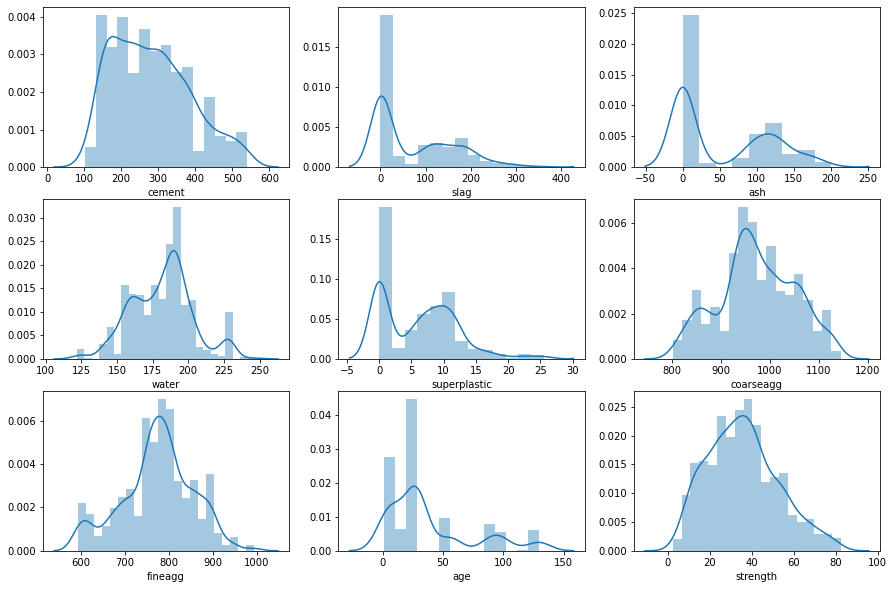

```python
#analysis of the body of distributions/tails
fig, axes = plt.subplots(nrows=3, ncols=3)
fig.set_size_inches(15,10)

#distplot
for i, column in enumerate(pdata.columns):
    sns.distplot(pdata[column],ax=axes[i//3,i%3])






# CEMENT, SLAG, ASH, SUPERPLASTIC, AGE are right skewed. As more number of data points are present on right tail.
# WATER, COARSEAGG, FINEAGG, STRENGTH are normally distributed

# ASH and SLAG even tend to be bimodal distribution
```

```python
# Finding duplicates in the records

duplicate = pdata[pdata.duplicated()]
duplicate
```

|  | cement | slag | ash | water | superplastic | coarseagg | fineagg | age | strength |
| --- | --- | --- | --- | --- | --- | --- | --- | --- | --- |
| 278 | 425.000000 | 106.300003 | 0.0 | 153.500000 | 16.5 | 852.099976 | 887.099976 | 3.0 | 33.400002 |
| 298 | 425.000000 | 106.300003 | 0.0 | 153.500000 | 16.5 | 852.099976 | 887.099976 | 3.0 | 33.400002 |
| 400 | 362.600006 | 189.000000 | 0.0 | 164.899994 | 11.6 | 944.700012 | 755.799988 | 3.0 | 35.299999 |
| 420 | 362.600006 | 189.000000 | 0.0 | 164.899994 | 11.6 | 944.700012 | 755.799988 | 3.0 | 35.299999 |
| 463 | 362.600006 | 189.000000 | 0.0 | 164.899994 | 11.6 | 944.700012 | 755.799988 | 56.0 | 77.300003 |
| 468 | 252.000000 | 0.000000 | 0.0 | 185.000000 | 0.0 | 1111.000000 | 784.000000 | 28.0 | 19.690001 |
| 482 | 425.000000 | 106.300003 | 0.0 | 153.500000 | 16.5 | 852.099976 | 887.099976 | 91.0 | 65.199997 |
| 493 | 362.600006 | 189.000000 | 0.0 | 164.899994 | 11.6 | 944.700012 | 755.799988 | 91.0 | 79.300003 |
| 517 | 425.000000 | 106.300003 | 0.0 | 153.500000 | 16.5 | 852.099976 | 887.099976 | 56.0 | 64.300003 |
| 525 | 362.600006 | 189.000000 | 0.0 | 164.899994 | 11.6 | 944.700012 | 755.799988 | 28.0 | 71.300003 |
| 527 | 425.000000 | 106.300003 | 0.0 | 153.500000 | 16.5 | 852.099976 | 887.099976 | 91.0 | 65.199997 |
| 576 | 362.600006 | 189.000000 | 0.0 | 164.899994 | 11.6 | 944.700012 | 755.799988 | 7.0 | 55.900002 |
| 577 | 425.000000 | 106.300003 | 0.0 | 153.500000 | 16.5 | 852.099976 | 887.099976 | 28.0 | 60.290001 |
| 604 | 362.600006 | 189.000000 | 0.0 | 164.899994 | 11.6 | 944.700012 | 755.799988 | 56.0 | 77.300003 |
| 733 | 362.600006 | 189.000000 | 0.0 | 164.899994 | 11.6 | 944.700012 | 755.799988 | 91.0 | 79.300003 |
| 738 | 362.600006 | 189.000000 | 0.0 | 164.899994 | 11.6 | 944.700012 | 755.799988 | 28.0 | 71.300003 |
| 766 | 362.600006 | 189.000000 | 0.0 | 164.899994 | 11.6 | 944.700012 | 755.799988 | 91.0 | 79.300003 |
| 830 | 425.000000 | 106.300003 | 0.0 | 153.500000 | 16.5 | 852.099976 | 887.099976 | 7.0 | 49.200001 |
| 880 | 425.000000 | 106.300003 | 0.0 | 153.500000 | 16.5 | 852.099976 | 887.099976 | 56.0 | 64.300003 |
| 884 | 425.000000 | 106.300003 | 0.0 | 153.500000 | 16.5 | 852.099976 | 887.099976 | 7.0 | 49.200001 |
| 892 | 362.600006 | 189.000000 | 0.0 | 164.899994 | 11.6 | 944.700012 | 755.799988 | 56.0 | 77.300003 |
| 933 | 362.600006 | 189.000000 | 0.0 | 164.899994 | 11.6 | 944.700012 | 755.799988 | 7.0 | 55.900002 |
| 943 | 362.600006 | 189.000000 | 0.0 | 164.899994 | 11.6 | 944.700012 | 755.799988 | 3.0 | 35.299999 |
| 967 | 362.600006 | 189.000000 | 0.0 | 164.899994 | 11.6 | 944.700012 | 755.799988 | 28.0 | 71.300003 |
| 992 | 425.000000 | 106.300003 | 0.0 | 153.500000 | 16.5 | 852.099976 | 887.099976 | 28.0 | 60.290001 |

```python
# from the above there seems to be duplicate records, we will now delete them
# keeping one of the occurence
pdata=pdata.drop_duplicates()

pdata
pdata.shape
```

```
(1005, 9)
```

### Bi-variate analysis

between the predictor variables and between the predictor variables and target column. Comment on your findings in terms of their relationship and degree of relation if any. Visualize the analysis using boxplots and pair plots, histograms, or density curves.

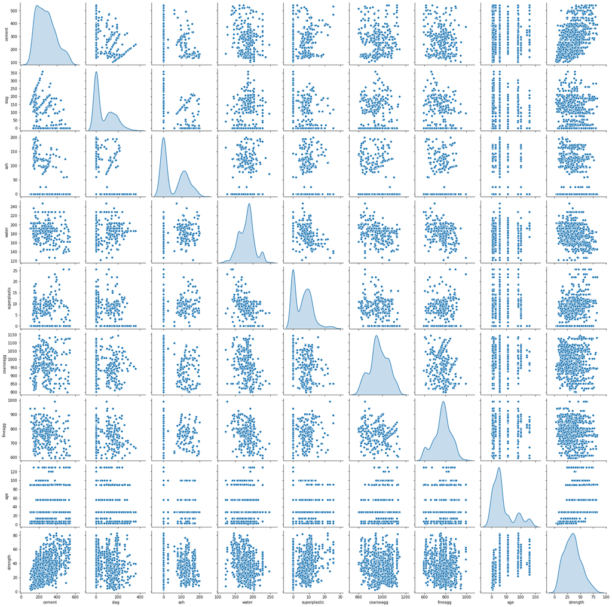

```python
sns.pairplot(pdata, diag_kind='kde')
```

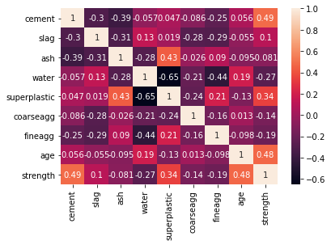

```python
# strength is correlated with cement and age a lot, and also with superplastic to some extent
# fineagg and superplastic is correlated
# coarseagg doesn't seem to be positively correlated with any, but
# negatively correlated with slag, water and superplastic
# superplastic & fineagg is negatively correlated with water
#  ash & slag are also negatively correlated with most of the attributes

corr_DF = pdata.corr()
sns.heatmap(corr_DF, annot = True)
```

```python
# for plotting box-plots, we have to convert the target to categorical datatype
# Let's say High, Medium, Low based on the strength number

pdata_new = pdata.copy(deep=True)
def lab(data2):
    if data2["strength"] <= 17:
        return "Low"
    if data2["strength"] >17 and data2["strength"] <= 28 :
        return "Medium"
    if data2["strength"] >28 :
        return "High"

pdata_new["strength_category"] = pdata_new.apply(lambda pdata_new:lab(pdata_new) ,axis =1)
```

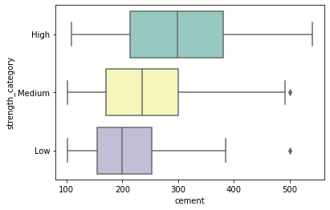

```python
sns.boxplot(x="cement", y="strength_category", data=pdata_new, palette="Set3")

# this also shows cement is directly related to strength
```

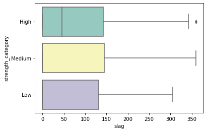

```python
sns.boxplot(x="slag", y="strength_category", data=pdata_new, palette="Set3")

# this also shows slag is somewhat related to strength, though not much
```

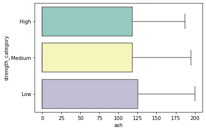

```python
sns.boxplot(x="ash", y="strength_category", data=pdata_new, palette="Set3")

# this also shows ash is not much related to strength
```

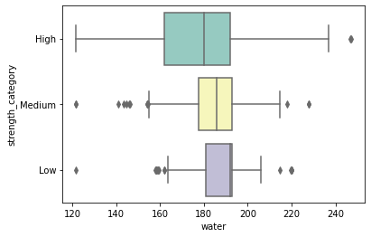

```python
sns.boxplot(x="water", y="strength_category", data=pdata_new, palette="Set3")

# negatively correlated
```

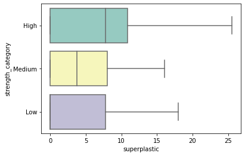

```python
sns.boxplot(x="superplastic", y="strength_category", data=pdata_new, palette="Set3")

# this also shows superplastic is positively correlated related to strength
```

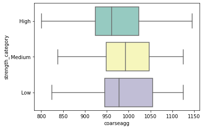

```python
sns.boxplot(x="coarseagg", y="strength_category", data=pdata_new, palette="Set3")

# this also shows coarseagg is  somewhat negatively correlated related to strength
```

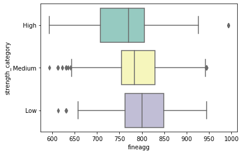

```python
sns.boxplot(x="fineagg", y="strength_category", data=pdata_new, palette="Set3")

# this also shows fineagg is somewhat negatively correlated related to strength
```

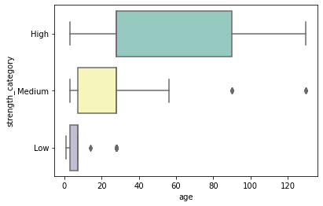

```python
sns.boxplot(x="age", y="strength_category", data=pdata_new, palette="Set3")

# this also shows age is highly positively correlated related to strength
```

### Feature Engineering techniques(10 marks)

Identify opportunities (if any) to extract new features from existing features, drop a feature(if required) Get the data model ready and do a train test split. Decide on the complexity of the model, should it be a simple linear model in terms of parameters or would a quadratic or higher degree.

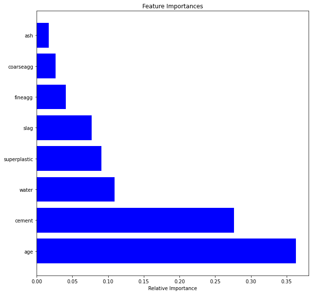

```python
# Trying to get the feature importance from RandomForestRegressor

# Split Train/Test data 70:30 ratio
from sklearn.model_selection import train_test_split

y = pdata['strength']
X = pdata.loc[:, pdata.columns != 'strength']

X_train, X_test, y_train, y_test = train_test_split (X, y, test_size=0.3, random_state=42,)
X_train.shape, X_test.shape, y_train.shape, y_test.shape

from sklearn.ensemble import RandomForestRegressor
rf = RandomForestRegressor()
rfm=rf.fit(X_train, y_train)
importances = rf.feature_importances_
indices = np.argsort(importances)[::-1][:15]
a = pdata.columns[:]
features= a.drop('strength',1)
#plot it
plt.figure(figsize=(10,10))
plt.title('Feature Importances')
plt.barh(range(len(indices)), importances[indices], color='b', align='center')
plt.yticks(range(len(indices)), features[indices])
plt.xlabel('Relative Importance')
plt.show()
```

```python
# from the correlation chart as well as above , doesn't seem we can combine any of the 2 features to extract a new one
# none of the features have absolute corr >= 0.8
# also since there are just 8 variables, and "ash" is the minimum importance, so we will see if dropping
# "ash" helps improve the accuracy and decrease the MSE

# before the modelling , we will scale the features and then go for various Models and Hyperparameters

# independent and dependent variables
X=pdata.loc[:,pdata.columns!='strength']
y=pdata.loc[:,pdata.columns=='strength']

# Split X and y into training and test set in 70:30 ratio
x_train,x_test,y_train,y_test=train_test_split(X,y,test_size=0.3,random_state=0)
columns=X_train.columns



#for normalization
from sklearn.preprocessing import StandardScaler
scaler=StandardScaler()
scaler.fit(x_train)
x_train = scaler.transform(x_train)
x_test = scaler.transform(x_test)
```

```python
# Now we will check all the models one by one

# LinearRegression


from sklearn import metrics
from sklearn.metrics import accuracy_score, f1_score, precision_score,confusion_matrix,mean_squared_error

from sklearn.linear_model import LinearRegression

# Fit the model on train
model = LinearRegression()
model.fit(x_train, y_train)
#predict on test
y_predict = model.predict(x_test)

model_score = model.score(x_test, y_test)
rmse= np.sqrt(mean_squared_error(y_test,y_predict))

#Store the accuracy results for each model in a dataframe for final comparison
results = pd.DataFrame({'Method':['Linear Regression'], 'Training accuracy': model.score(x_train,y_train),
                        'Testing accuracy': model_score, 'MSE': rmse})
results = results[['Method', 'Training accuracy','Testing accuracy','MSE']]
results
```

|  | Method | Training accuracy | Testing accuracy | MSE |
| --- | --- | --- | --- | --- |
| 0 | Linear Regression | 0.723869 | 0.701664 | 8.714262 |

```python
# LinearRegression - dropped "ash"


# from sklearn import metrics
# from sklearn.metrics import accuracy_score, f1_score, precision_score,confusion_matrix,mean_squared_error

# from sklearn.linear_model import LinearRegression
# x_train=x_train.drop('ash', axis=1)
# x_test=x_test.drop('ash', axis=1)

# print(x_train.head())
# print(x_test.head())

# # Fit the model on train
# model = LinearRegression()
# model.fit(x_train, y_train)
# #predict on test
# y_predict = model.predict(x_test)

# model_score = model.score(x_test, y_test)
# rmse= np.sqrt(mean_squared_error(y_test,y_predict))

# #Store the accuracy results for each model in a dataframe for final comparison
# results = pd.DataFrame({'Method':['Linear Regression without ash'], 'Training accuracy': model.score(x_train,y_train),
#                         'Testing accuracy': model_score, 'MSE': rmse})
# results = results[['Method', 'Training accuracy','Testing accuracy','MSE']]
# results

### Method	Training accuracy	Testing accuracy	MSE
### 0	Linear Regression without ash	0.71057	0.640891	9.252379

# MSE score increased and accuracy decreased after dropping "ash", so not dropping the column
# so since this is pretty small data set - we are neither dropping not feature engineering any column as corr are not high
```

```python
# LinearRegression with Lasso Regularization


from sklearn import metrics

from sklearn.linear_model import Lasso

# Fit the model on train
model = Lasso()
model.fit(x_train, y_train)
#predict on test
y_predict = model.predict(x_test)

model_score = model.score(x_test, y_test)
rmse= np.sqrt(mean_squared_error(y_test,y_predict))

#Store the accuracy results for each model in a dataframe for final comparison
resultsnew = pd.DataFrame({'Method':['Lasso (alpha=1)'], 'Training accuracy': model.score(x_train,y_train),
                        'Testing accuracy': model_score, 'MSE': rmse})
results = pd.concat([results, resultsnew])
results = results[['Method', 'Training accuracy','Testing accuracy','MSE']]
results
```

|  | Method | Training accuracy | Testing accuracy | MSE |
| --- | --- | --- | --- | --- |
| 0 | Linear Regression | 0.723869 | 0.701664 | 8.714262 |
| 0 | Lasso (alpha=1) | 0.679513 | 0.655787 | 9.360326 |

```python
# LinearRegression with Lasso Regularization


from sklearn import metrics

from sklearn.linear_model import Lasso

# Fit the model on train
model = Lasso(alpha=0.5)
model.fit(x_train, y_train)
#predict on test
y_predict = model.predict(x_test)

model_score = model.score(x_test, y_test)
rmse= np.sqrt(mean_squared_error(y_test,y_predict))

#Store the accuracy results for each model in a dataframe for final comparison
resultsnew = pd.DataFrame({'Method':['Lasso (alpha=0.5)'], 'Training accuracy': model.score(x_train,y_train),
                        'Testing accuracy': model_score, 'MSE': rmse})
results = pd.concat([results, resultsnew])
results = results[['Method', 'Training accuracy','Testing accuracy','MSE']]
results
```

|  | Method | Training accuracy | Testing accuracy | MSE |
| --- | --- | --- | --- | --- |
| 0 | Linear Regression | 0.723869 | 0.701664 | 8.714262 |
| 0 | Lasso (alpha=1) | 0.679513 | 0.655787 | 9.360326 |
| 0 | Lasso (alpha=0.5) | 0.711133 | 0.689902 | 8.884383 |

```python
# LinearRegression with Lasso Regularization


from sklearn import metrics

from sklearn.linear_model import Lasso

# Fit the model on train
model = Lasso(alpha=0.1)
model.fit(x_train, y_train)
#predict on test
y_predict = model.predict(x_test)

model_score = model.score(x_test, y_test)
rmse= np.sqrt(mean_squared_error(y_test,y_predict))

#Store the accuracy results for each model in a dataframe for final comparison
resultsnew = pd.DataFrame({'Method':['Lasso (alpha=0.1)'], 'Training accuracy': model.score(x_train,y_train),
                        'Testing accuracy': model_score, 'MSE': rmse})
results = pd.concat([results, resultsnew])
results = results[['Method', 'Training accuracy','Testing accuracy','MSE']]
results
```

|  | Method | Training accuracy | Testing accuracy | MSE |
| --- | --- | --- | --- | --- |
| 0 | Linear Regression | 0.723869 | 0.701664 | 8.714262 |
| 0 | Lasso (alpha=1) | 0.679513 | 0.655787 | 9.360326 |
| 0 | Lasso (alpha=0.5) | 0.711133 | 0.689902 | 8.884383 |
| 0 | Lasso (alpha=0.1) | 0.722790 | 0.702171 | 8.706856 |

```python
# LinearRegression with Ridge Regularization


from sklearn import metrics

from sklearn.linear_model import Ridge

# Fit the model on train
model = Ridge(alpha=1)
model.fit(x_train, y_train)
#predict on test
y_predict = model.predict(x_test)

model_score = model.score(x_test, y_test)
rmse= np.sqrt(mean_squared_error(y_test,y_predict))

#Store the accuracy results for each model in a dataframe for final comparison
resultsnew = pd.DataFrame({'Method':['Ridge (alpha=1)'], 'Training accuracy': model.score(x_train,y_train),
                        'Testing accuracy': model_score, 'MSE': rmse})
results = pd.concat([results, resultsnew])
results = results[['Method', 'Training accuracy','Testing accuracy','MSE']]
results
```

|  | Method | Training accuracy | Testing accuracy | MSE |
| --- | --- | --- | --- | --- |
| 0 | Linear Regression | 0.723869 | 0.701664 | 8.714262 |
| 0 | Lasso (alpha=1) | 0.679513 | 0.655787 | 9.360326 |
| 0 | Lasso (alpha=0.5) | 0.711133 | 0.689902 | 8.884383 |
| 0 | Lasso (alpha=0.1) | 0.722790 | 0.702171 | 8.706856 |
| 0 | Ridge (alpha=1) | 0.723841 | 0.701886 | 8.711009 |

```python
# LinearRegression with Ridge Regularization


from sklearn import metrics

from sklearn.linear_model import Ridge

# Fit the model on train
model = Ridge(alpha=0.5)
model.fit(x_train, y_train)
#predict on test
y_predict = model.predict(x_test)

model_score = model.score(x_test, y_test)
rmse= np.sqrt(mean_squared_error(y_test,y_predict))

#Store the accuracy results for each model in a dataframe for final comparison
resultsnew = pd.DataFrame({'Method':['Ridge (alpha=0.5)'], 'Training accuracy': model.score(x_train,y_train),
                        'Testing accuracy': model_score, 'MSE': rmse})
results = pd.concat([results, resultsnew])
results = results[['Method', 'Training accuracy','Testing accuracy','MSE']]
results
```

|  | Method | Training accuracy | Testing accuracy | MSE |
| --- | --- | --- | --- | --- |
| 0 | Linear Regression | 0.723869 | 0.701664 | 8.714262 |
| 0 | Lasso (alpha=1) | 0.679513 | 0.655787 | 9.360326 |
| 0 | Lasso (alpha=0.5) | 0.711133 | 0.689902 | 8.884383 |
| 0 | Lasso (alpha=0.1) | 0.722790 | 0.702171 | 8.706856 |
| 0 | Ridge (alpha=1) | 0.723841 | 0.701886 | 8.711009 |
| 0 | Ridge (alpha=0.5) | 0.723861 | 0.701787 | 8.712466 |

```python
# LinearRegression with Ridge Regularization


from sklearn import metrics

from sklearn.linear_model import Ridge

# Fit the model on train
model = Ridge(alpha=0.1)
model.fit(x_train, y_train)
#predict on test
y_predict = model.predict(x_test)

model_score = model.score(x_test, y_test)
rmse= np.sqrt(mean_squared_error(y_test,y_predict))

#Store the accuracy results for each model in a dataframe for final comparison
resultsnew = pd.DataFrame({'Method':['Ridge (alpha=0.1)'], 'Training accuracy': model.score(x_train,y_train),
                        'Testing accuracy': model_score, 'MSE': rmse})
results = pd.concat([results, resultsnew])
results = results[['Method', 'Training accuracy','Testing accuracy','MSE']]
results
```

|  | Method | Training accuracy | Testing accuracy | MSE |
| --- | --- | --- | --- | --- |
| 0 | Linear Regression | 0.723869 | 0.701664 | 8.714262 |
| 0 | Lasso (alpha=1) | 0.679513 | 0.655787 | 9.360326 |
| 0 | Lasso (alpha=0.5) | 0.711133 | 0.689902 | 8.884383 |
| 0 | Lasso (alpha=0.1) | 0.722790 | 0.702171 | 8.706856 |
| 0 | Ridge (alpha=1) | 0.723841 | 0.701886 | 8.711009 |
| 0 | Ridge (alpha=0.5) | 0.723861 | 0.701787 | 8.712466 |
| 0 | Ridge (alpha=0.1) | 0.723868 | 0.701690 | 8.713874 |

```python
# PolynomialFeatures with Degree 2


from sklearn import metrics


from sklearn.preprocessing import PolynomialFeatures
from sklearn import linear_model

# Create linear regression object
poly = PolynomialFeatures(degree=2)

x_train = poly.fit_transform(x_train)
x_test = poly.fit_transform(x_test)

model = linear_model.LinearRegression()
model.fit(x_train, y_train)

print(model.score(x_train, y_train))



model_score = model.score(x_test, y_test)
rmse= np.sqrt(mean_squared_error(y_test,y_predict))

#Store the accuracy results for each model in a dataframe for final comparison
resultsnew = pd.DataFrame({'Method':['PolynomialFeatures (degree=2)'], 'Training accuracy': model.score(x_train,y_train),
                        'Testing accuracy': model_score, 'MSE': rmse})
results = pd.concat([results, resultsnew])
results = results[['Method', 'Training accuracy','Testing accuracy','MSE']]
results
```

```
0.8663047595612086
```

|  | Method | Training accuracy | Testing accuracy | MSE |
| --- | --- | --- | --- | --- |
| 0 | Linear Regression | 0.723869 | 0.701664 | 8.714262 |
| 0 | Lasso (alpha=1) | 0.679513 | 0.655787 | 9.360326 |
| 0 | Lasso (alpha=0.5) | 0.711133 | 0.689902 | 8.884383 |
| 0 | Lasso (alpha=0.1) | 0.722790 | 0.702171 | 8.706856 |
| 0 | Ridge (alpha=1) | 0.723841 | 0.701886 | 8.711009 |
| 0 | Ridge (alpha=0.5) | 0.723861 | 0.701787 | 8.712466 |
| 0 | Ridge (alpha=0.1) | 0.723868 | 0.701690 | 8.713874 |
| 0 | PolynomialFeatures (degree=2) | 0.866305 | 0.820284 | 8.713874 |

```python
# # PolynomialFeatures with Degree 3


# from sklearn import metrics


# from sklearn.preprocessing import PolynomialFeatures
# from sklearn import linear_model

# # Create linear regression object
# poly = PolynomialFeatures(degree=3)

# x_train = poly.fit_transform(x_train)
# x_test = poly.fit_transform(x_test)

# model = linear_model.LinearRegression()
# model.fit(x_train, y_train)

# print(model.score(x_train, y_train))



# model_score = model.score(x_test, y_test)
# rmse= np.sqrt(mean_squared_error(y_test,y_predict))

# #Store the accuracy results for each model in a dataframe for final comparison
# resultsnew = pd.DataFrame({'Method':['PolynomialFeatures (degree=3)'], 'Training accuracy': model.score(x_train,y_train),
#                         'Testing accuracy': model_score, 'RMSE': rmse})
# results = pd.concat([results, resultsnew])
# results = results[['Method', 'Training accuracy','Testing accuracy','RMSE']]
# results
```

```python
# Polynomial with Lasso
# from sklearn.linear_model import Lasso
# alphas= [0.1,0.5,1]
# poly = PolynomialFeatures(degree=2)
# x_train = poly.fit_transform(x_train)
# x_test = poly.fit_transform(x_test)
# for j in alphas:
#     model = Lasso(alpha=j)
#     model.fit(x_train, y_train)

#     print(model.score(x_train, y_train))
#     model_score = model.score(x_test, y_test)
#     rmse= np.sqrt(mean_squared_error(y_test,y_predict))

#     #Store the accuracy results for each model in a dataframe for final comparison
#     resultsnew = pd.DataFrame({'Method':['PolynomialFeatures with Lasso (degree=',i,')','(alpha=',j,')'], 'Training accuracy': model.score(x_train,y_train),
#                             'Testing accuracy': model_score, 'RMSE': rmse})
#     results = pd.concat([results, resultsnew])
#     results = results[['Method', 'Training accuracy','Testing accuracy','RMSE']]
#     results
# print(results)
```

```python
# Polynomial with Ridge
# from sklearn.linear_model import Ridge
# alphas= [0.1,0.5,1]
# poly = PolynomialFeatures(degree=2)
# x_train = poly.fit_transform(x_train)
# x_test = poly.fit_transform(x_test)
# for j in alphas:
#     model = Ridge(alpha=j)
#     model.fit(x_train, y_train)

#     print(model.score(x_train, y_train))
#     model_score = model.score(x_test, y_test)
#     rmse= np.sqrt(mean_squared_error(y_test,y_predict))
#     print(model.score(x_train, y_train), model_score, rmse)
#     #Store the accuracy results for each model in a dataframe for final comparison
#     resultsnew = pd.DataFrame({'Method':['PolynomialFeatures with Ridge (degree=',i,')','(alpha=',j,')'], 'Training accuracy': model.score(x_train,y_train),
#                             'Testing accuracy': model_score, 'RMSE': rmse})
#     results = pd.concat([results, resultsnew])
#     results = results[['Method', 'Training accuracy','Testing accuracy','RMSE']]
#     results
# print(results)
```

```python
# From the above it seems that Polynomial with degree 2 is better than simple linear model...
# Regularization, Lasso or Ridge not heping much - so we will not consider them. Till now Polynomial with degree 2 is
# showing the best results.
```